# Experimental treatment with edaravone in a mouse model of spinocerebellar ataxia 1

# 6 Thigmotaxis in open filed per distance

## 6.1 Data exploration

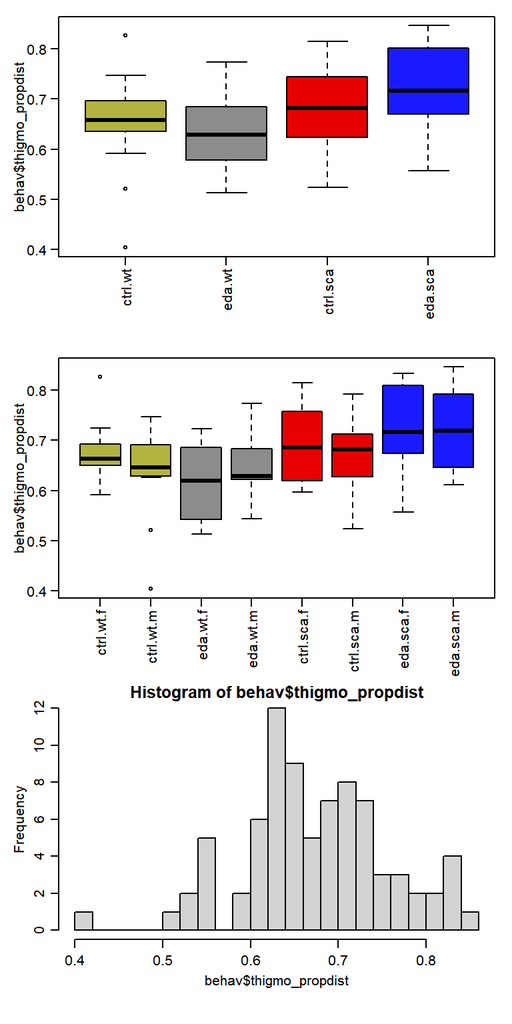

```r
## set spacing
par(mar=c(5,3.5,1,1))
par(mgp=c(1.9,0.7,0))
par(mfrow=c(3,1))

## plotting
plot(behav$thigmo_propdist ~ behav$group,las=2,xlab="",
     col=cola)

plot(behav$thigmo_propdist ~ behav$group_sex,las=2,xlab="",
     col=cola[c(1,1,2,2,3,3,4,4)])

hist(behav$thigmo_propdist, 20)
```

No apparent effect of sex. Distribution looks relatively similar across the groups and symmetrical. We will fit both beta regression (the outcome is proportion from 0 to 1) or Gaussian models

## 6.2 Modelling

### 6.2.1 Prior specification

As the study Tichanek et al. used different size of the zone along the walls (5 vs. 7 cm), prior for intercept will be established according to data only

Beta model

```r
behav$group<-relevel(behav$group,ref='ctrl.sca')

logit(mean(behav$thigmo_propdist))
```

```
[1] 0.7182175
```

```r
sd(logit(behav[behav$genotype=="sca",]$thigmo_propdist))*c(5, 1.2)
```

```
[1] 2.0370066 0.4888816
```

```r
sd(logit(behav$thigmo_propdist))*c(5, 1.2)
```

```
[1] 2.0122953 0.4829509
```

```r
model_pri<-glmmTMB(of.distance_on_edges_narrow~genotype,
                   family=beta_family(link="logit"),data=young_scirep)
summary(model_pri)
```

```
 Family: beta  ( logit )
Formula:          of.distance_on_edges_narrow ~ genotype
Data: young_scirep

     AIC      BIC   logLik deviance df.resid
  -133.8   -127.8     69.9   -139.8       52


Dispersion parameter for beta family (): 35.5

Conditional model:
            Estimate Std. Error z value Pr(>|z|)
(Intercept)  1.43709    0.07606  18.894  < 2e-16 ***
genotypew   -0.48881    0.10516  -4.648 3.35e-06 ***
---
Signif. codes:  0 '***' 0.001 '**' 0.01 '*' 0.05 '.' 0.1 ' ' 1
```

```r
prios(model_pri)
```

```
  Estimate
-0.2826973  0.4240460
```

Defining prior for beta model

```r
prior01 <- c(set_prior("student_t(3, 0.71, 2)", class = "b", coef = "Intercept"),
             set_prior("normal(-0.28, 0.42)", class = "b", coef = "groupctrl.wt"),
             set_prior("normal(-0.28, 0.42)", class = "b", coef = "groupeda.wt"),
             set_prior("normal(0, 1.2)"  , class = "b", coef = "groupeda.sca"))
```

Priors for Gaussian model

```r
mean(behav$thigmo_propdist)
```

```
[1] 0.6722144
```

```r
sd((behav[behav$genotype=="sca",]$thigmo_propdist))*c(5, 1.2)
```

```
[1] 0.40806301 0.09793512
```

```r
sd((behav$thigmo_propdist))*c(5, 1.2)
```

```
[1] 0.4225520 0.1014125
```

```r
model_pri<-glmmTMB(of.distance_on_edges_narrow~genotype,data=young_scirep)
summary(model_pri)
```

```
 Family: gaussian  ( identity )
Formula:          of.distance_on_edges_narrow ~ genotype
Data: young_scirep

     AIC      BIC   logLik deviance df.resid
  -132.7   -126.7     69.3   -138.7       52


Dispersion estimate for gaussian family (sigma^2): 0.0047

Conditional model:
            Estimate Std. Error z value Pr(>|z|)
(Intercept)  0.80832    0.01252   64.56  < 2e-16 ***
genotypew   -0.08811    0.01857   -4.74 2.09e-06 ***
---
Signif. codes:  0 '***' 0.001 '**' 0.01 '*' 0.05 '.' 0.1 ' ' 1
```

```r
prios(model_pri)
```

```
   Estimate
-0.05170907  0.07756361
```

Defining the prior for Gaussian model

```r
prior02 <- c(set_prior("student_t(3,0.67,0.41)", class = "b", coef = "Intercept"),
             set_prior("normal(-0.052,0.08)", class = "b", coef = "groupctrl.wt"),
             set_prior("normal(-0.052,0.08)", class = "b", coef = "groupeda.wt"),
             set_prior("normal(0,0.1)"  , class = "b", coef = "groupeda.sca"))
```

### 6.2.2 Fitting models and convergence and ESS check

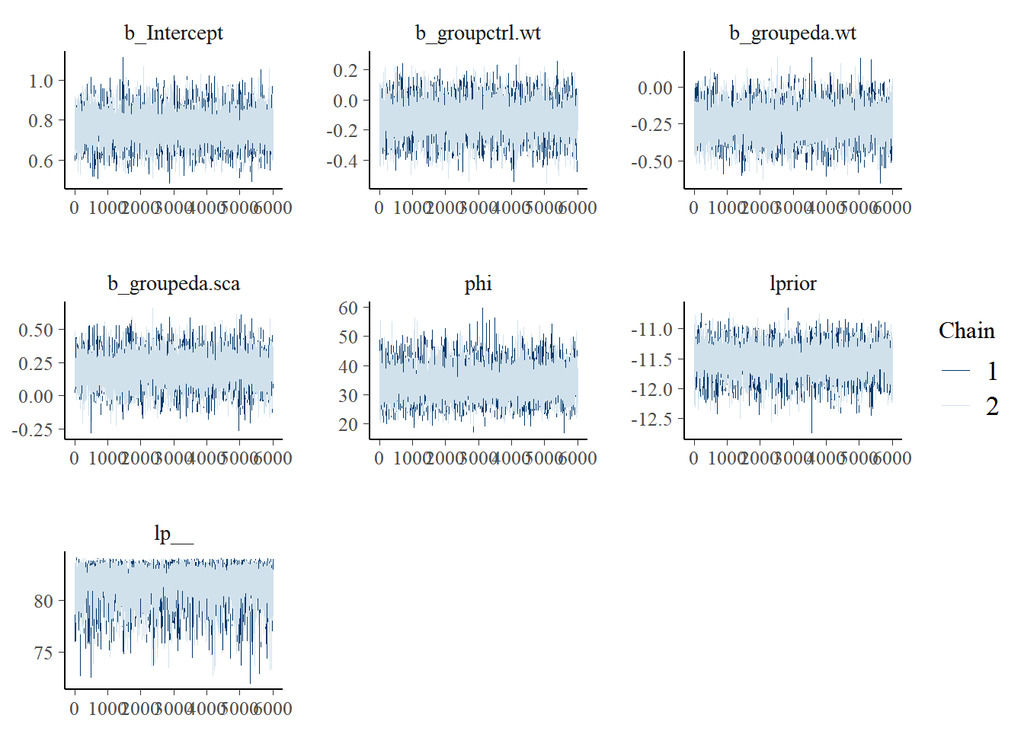

```r
of_thigmo_model_01 <- run_model(
            brm(thigmo_propdist ~0+Intercept+group,
                      data=behav, prior = prior01,
                      family=Beta(link="logit", link_phi="log"),
                      save_pars = save_pars(all = TRUE),
                      iter=8000, warmup=2000,chains=2,cores=1,seed=17,
                      control = list(adapt_delta = 0.99)),
                  'output/brm/of_thigmo_model_01', reuse = TRUE)



of_thigmo_model_02 <- run_model(
              brm(thigmo_propdist~0+Intercept+group,
                      data=behav, prior = prior02,
                      family=gaussian(),
                      save_pars = save_pars(all = TRUE),
                      iter=8000, warmup=2000,chains=2,cores=1,seed=17,
                      control = list(adapt_delta = 0.99)),
                  'output/brm/of_thigmo_model_02', reuse = TRUE)

mcmc_trace(of_thigmo_model_01)
```

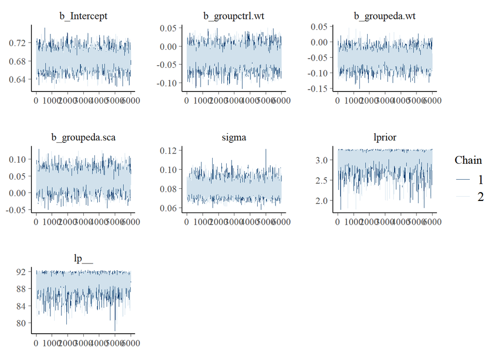

```r
mcmc_trace(of_thigmo_model_02)
```

```r
summary(of_thigmo_model_01)
```

```
 Family: beta
  Links: mu = logit; phi = identity
Formula: thigmo_propdist ~ 0 + Intercept + group
   Data: behav (Number of observations: 80)
  Draws: 2 chains, each with iter = 8000; warmup = 2000; thin = 1;
         total post-warmup draws = 12000

Population-Level Effects:
             Estimate Est.Error l-95% CI u-95% CI Rhat Bulk_ESS Tail_ESS
Intercept        0.77      0.08     0.61     0.93 1.00     4264     4931
groupctrl.wt    -0.13      0.11    -0.35     0.09 1.00     4930     5811
groupeda.wt     -0.24      0.11    -0.45    -0.03 1.00     4837     5764
groupeda.sca     0.19      0.12    -0.03     0.42 1.00     4962     6159

Family Specific Parameters:
    Estimate Est.Error l-95% CI u-95% CI Rhat Bulk_ESS Tail_ESS
phi    34.10      5.38    24.45    45.48 1.00     6350     6426

Draws were sampled using sampling(NUTS). For each parameter, Bulk_ESS
and Tail_ESS are effective sample size measures, and Rhat is the potential
scale reduction factor on split chains (at convergence, Rhat = 1).
```

```r
summary(of_thigmo_model_02)
```

```
 Family: gaussian
  Links: mu = identity; sigma = identity
Formula: thigmo_propdist ~ 0 + Intercept + group
   Data: behav (Number of observations: 80)
  Draws: 2 chains, each with iter = 8000; warmup = 2000; thin = 1;
         total post-warmup draws = 12000

Population-Level Effects:
             Estimate Est.Error l-95% CI u-95% CI Rhat Bulk_ESS Tail_ESS
Intercept        0.68      0.02     0.65     0.72 1.00     4017     6156
groupctrl.wt    -0.03      0.02    -0.08     0.02 1.00     4983     7241
groupeda.wt     -0.05      0.02    -0.10    -0.01 1.00     4873     6445
groupeda.sca     0.04      0.02    -0.01     0.08 1.00     4968     7196

Family Specific Parameters:
      Estimate Est.Error l-95% CI u-95% CI Rhat Bulk_ESS Tail_ESS
sigma     0.08      0.01     0.07     0.09 1.00     7321     6719

Draws were sampled using sampling(NUTS). For each parameter, Bulk_ESS
and Tail_ESS are effective sample size measures, and Rhat is the potential
scale reduction factor on split chains (at convergence, Rhat = 1).
```

Convergence and ESS of both models are OK

### 6.2.3 PPC

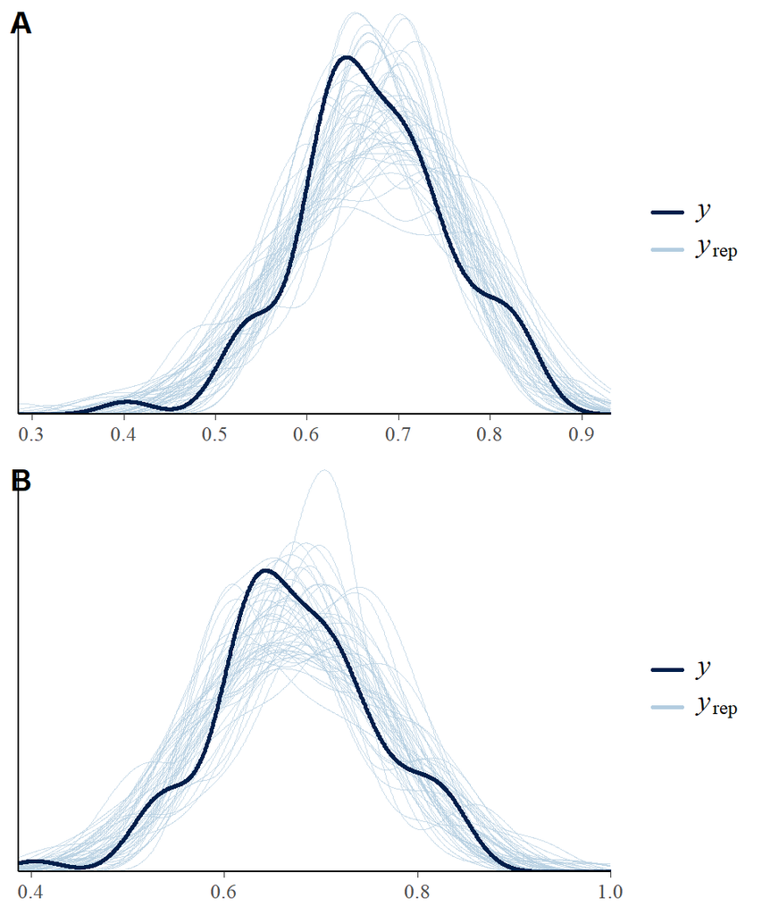

```r
pla<-pp_check(of_thigmo_model_01,type='dens_overlay',ndraws = 50)
plb<-pp_check(of_thigmo_model_02,type='dens_overlay',ndraws = 50)
plot_grid(pla, plb, labels=c("A", "B"), ncol = 1, nrow = 2)
```

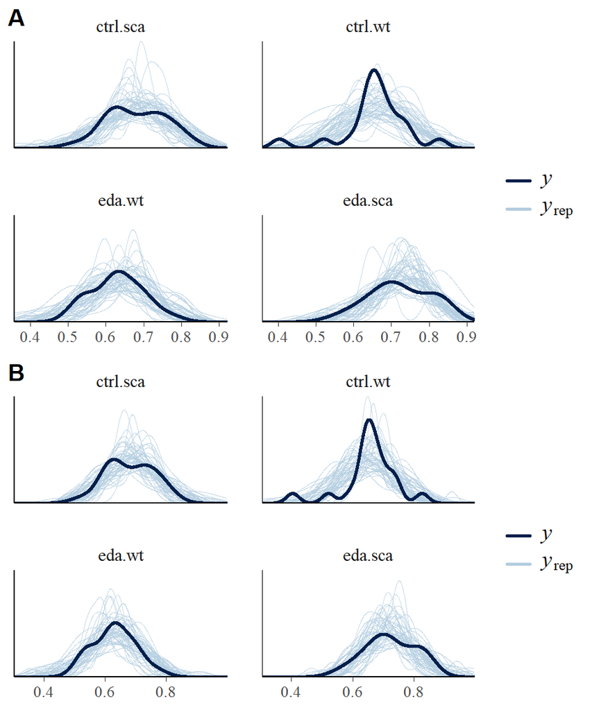

```r
pla<-pp_check(of_thigmo_model_01,type='dens_overlay_grouped',ndraws = 50,group='group')
plb<-pp_check(of_thigmo_model_02,type='dens_overlay_grouped',ndraws = 50,group='group')
plot_grid(pla, plb, labels=c("A", "B"), ncol = 1, nrow = 2)
```

```r
pla<-pp_check(of_thigmo_model_01,type='scatter_avg')
```

```
Using all posterior draws for ppc type 'scatter_avg' by default.
```

```r
plb<-pp_check(of_thigmo_model_02,type='scatter_avg')
```

```
Using all posterior draws for ppc type 'scatter_avg' by default.
```

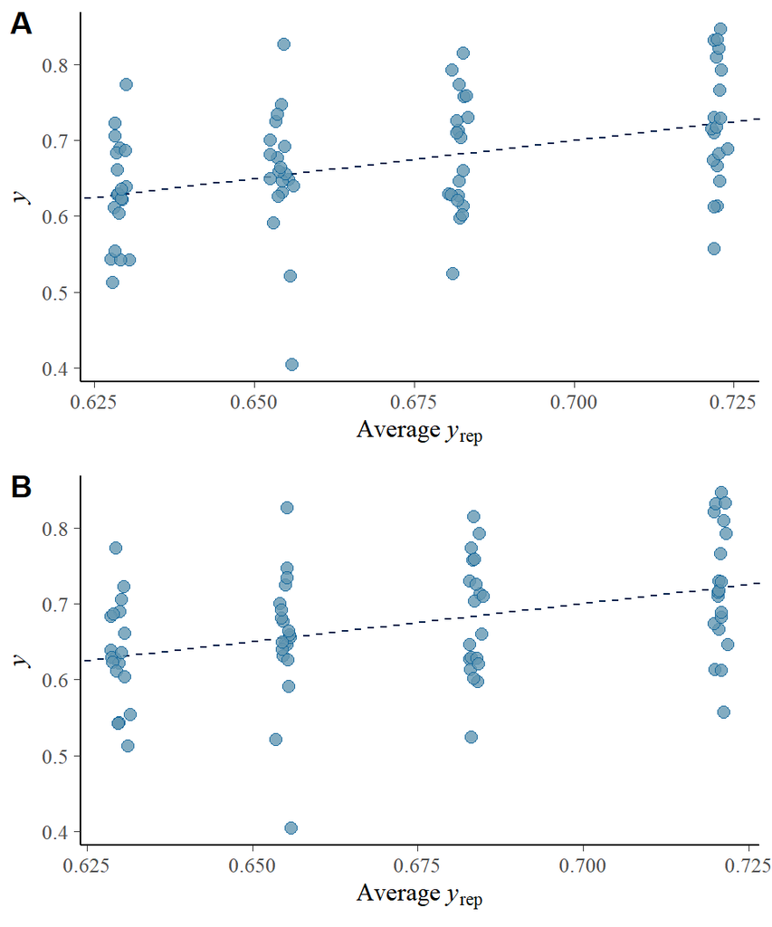

```r
plot_grid(pla, plb, labels=c("A", "B"), ncol = 1, nrow = 2)
```

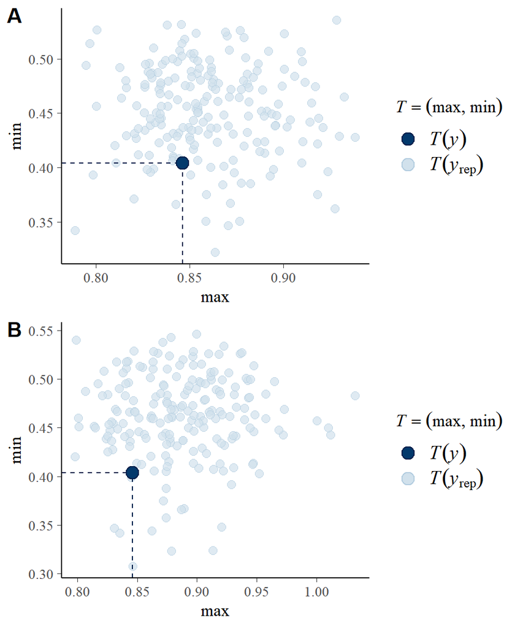

```r
pla<-pp_check(of_thigmo_model_01,type="stat_2d", stat = c("max", "min"),ndraws=200)
plb<-pp_check(of_thigmo_model_02,type="stat_2d", stat = c("max", "min"),ndraws=200)
plot_grid(pla, plb, labels=c("A", "B"), ncol = 1, nrow = 2)
```

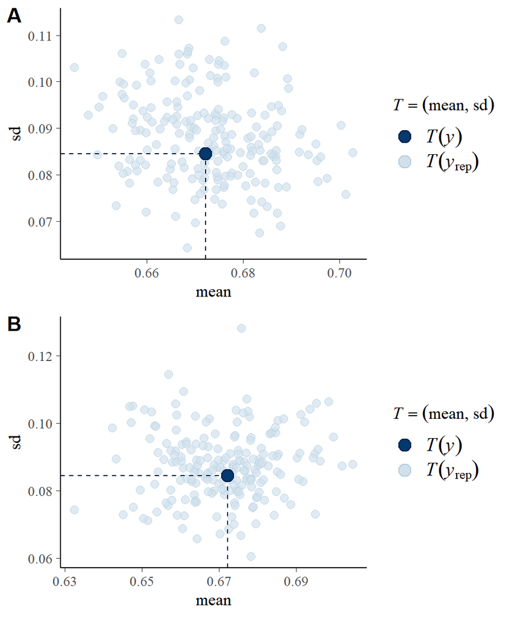

```r
pla<-pp_check(of_thigmo_model_01,type="stat_2d", stat = c("mean", "sd"),ndraws=200)
plb<-pp_check(of_thigmo_model_02,type="stat_2d", stat = c("mean", "sd"),ndraws=200)
plot_grid(pla, plb, labels=c("A", "B"), ncol = 1, nrow = 2)
```

```r
### Are there too influential observations?
par(mfrow=c(1,2))
plot(loo(of_thigmo_model_01));loo(of_thigmo_model_01)
```

```
Computed from 12000 by 80 log-likelihood matrix

         Estimate   SE
elpd_loo     87.0  6.6
p_loo         4.8  1.0
looic      -174.1 13.3
------
Monte Carlo SE of elpd_loo is 0.0.

All Pareto k estimates are good (k < 0.5).
See help('pareto-k-diagnostic') for details.
```

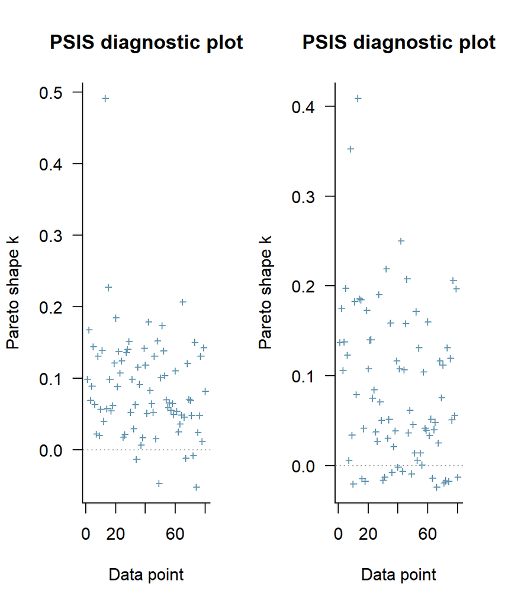

```
Computed from 12000 by 80 log-likelihood matrix

         Estimate   SE
elpd_loo     86.6  7.1
p_loo         4.9  1.2
looic      -173.1 14.3
------
Monte Carlo SE of elpd_loo is 0.0.

All Pareto k estimates are good (k < 0.5).
See help('pareto-k-diagnostic') for details.
```

```r
plot(loo(of_thigmo_model_02));loo(of_thigmo_model_02)
```

Both models seem OK. Beta model is more natural for proportional data and thus will be preferred

## 6.3 Posterior draws extraction and visualization

Posterior samples extraction

```r
post_fix<-as.data.frame(of_thigmo_model_01, variable = c("b_Intercept","b_groupctrl.wt",
                                                       "b_groupeda.wt","b_groupeda.sca"))
names(post_fix)[1]<-"sca_ctrl"

post_fix$wt_ctrl<-post_fix$sca_ctrl+post_fix$b_groupctrl.wt
post_fix$wt_eda<-post_fix$sca_ctrl+post_fix$b_groupeda.wt
post_fix$sca_eda<-post_fix$sca_ctrl+post_fix$b_groupeda.sca
post_fix$wt_contrast<-post_fix$wt_eda-post_fix$wt_ctrl

groupquant<-sapply(post_fix[,c(5,6,1,7)],function(p) quantile(p, probs = c(0.025,0.975,0.5)))
groupquant<-inv.logit(groupquant)
```

Plotting

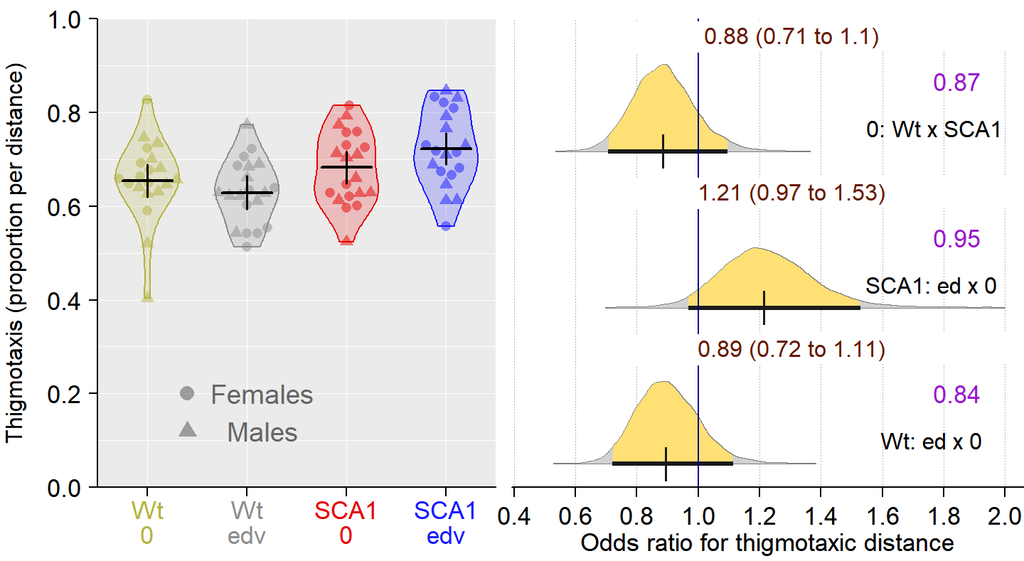

```r
behav$group<-factor(behav$group,levels=c('ctrl.wt','eda.wt','ctrl.sca','eda.sca'))

par(mfrow=c(1,2))
par(mar=c(2,3,0,0))
par(mgp=c(2,0.6,0))
range<-c(0,1);scal<-range[2]-range[1]
xrange<-c(0.5,4.5);xscal=xrange[2]-xrange[1]
plot(NULL,xlim=c(xrange[1],xrange[2]),ylim=c(range[1],range[2]),xlab="",
     ylab="Thigmotaxis (proportion per distance)",las=1, axes=FALSE,cex.lab=1)

rect(xrange[1],range[2],xrange[2],range[1],col="grey92",border=NA)
x<-range[1]
repeat{
  lines(c(xrange[1],xrange[2]),c(x,x),col="white",lwd=0.7)
  x=x+0.1;if(x>range[2]){break}}

x<-1
repeat{
  lines(c(x,x),c(range[1],range[2]),col="white",lwd=0.7)
  x=x+1;if(x>4.5){break}}

vioplot(behav$thigmo_propdist~behav$group,col=colb,at=c(1:4),add=T,
        border=cola,axes=FALSE,drawRect=F,lwd=1,wex=0.8)

beeswarm(behav$thigmo_propdist~behav$group,col=colc,at=c(1:4),add=T,pwpch=(16.5+behav$sex_num) )

tp<-(groupquant[3,])
xx<-1;wid=0.25
repeat{
  lines(c(xx-wid,xx+wid),c(tp[xx],tp[xx]),lwd=2,col="black");
  lines(c(xx,xx),c(groupquant[1,xx],groupquant[2,xx]),lwd=1.7,col="black")
  xx<-xx+1
  if(xx>4){break}}

tckk=-0.02
axis(2,las=2,cex.axis=1.1,at=seq(range[1],range[2],by=0.2),
     labels=c(rep("",length(seq(range[1],range[2],by=0.2)))),pos=xrange[1],tck=tckk)
axis(2,las=2,cex.axis=1.1,at=seq(range[1],range[2],by=0.2),pos=xrange[1],tck=tckk)

axis(side=1,las=1,cex.axis=1.1,at=c(seq(1,4,by=1)),
     labels=c(rep("",length(seq(1,4,by=1)))),pos=range[1],tck=tckk)
lines(c(xrange[1],xrange[2]),c(range[1],range[1]))
text(c(1:4),c(rep(range[1]-0.046*scal,4)),xpd=T,cex=1.1,col=cola,
     c("Wt","Wt", "SCA1", "SCA1"))
ypo<-c(range[1]-0.1*scal,range[1]-0.1*scal)
text(c(1:4),c(ypo[1],ypo[2],ypo[1],ypo[2]),xpd=T,cex=1.1,col=cola,
     c("0","edv", "0", "edv"))

ypos<-0.2;xpos=1.4
points(xpos,ypos,pch=16,cex=1.4,col=rgb(0.4,0.4,0.4,alpha=0.6))
text(xpos+0.19*xscal,ypos,"Females",col="grey40",cex=1.2)
points(xpos,ypos-0.08*scal,pch=17,cex=1.4,col=rgb(0.4,0.4,0.4,alpha=0.6))
text(xpos+0.19*xscal,ypos-0.08*scal,"Males",col="grey40",cex=1.2)

### probability distributions --------
par(mar=c(2,0,0,0))
dif<-data.frame(post_fix$wt_contrast,post_fix$b_groupeda.sca,
                post_fix$b_groupctrl.wt)
dif<-exp(dif)

yla<-"Odds ratio for thigmotaxic distance"
tckk=-0.018
ste<-seq(0.2,2.2,by=0.2)
mons_poste(dif,1)

zpos=seq(0,1,1/3)
xx=1;ind=0.3;xpol<-1.77
text(xpol,zpos[xx]+zpos[2]*ind,
     "Wt: ed x 0 ",cex=1)
xx=xx+1

text(xpol,zpos[xx]+zpos[2]*ind,
     "SCA1: ed x 0 ",cex=1)
xx=xx+1

text(xpol,zpos[xx]+zpos[2]*ind,
     "0: Wt x SCA1",cex=1)
```

# 7 Thigmotaxis in OF per time

## 7.1 Data exploration

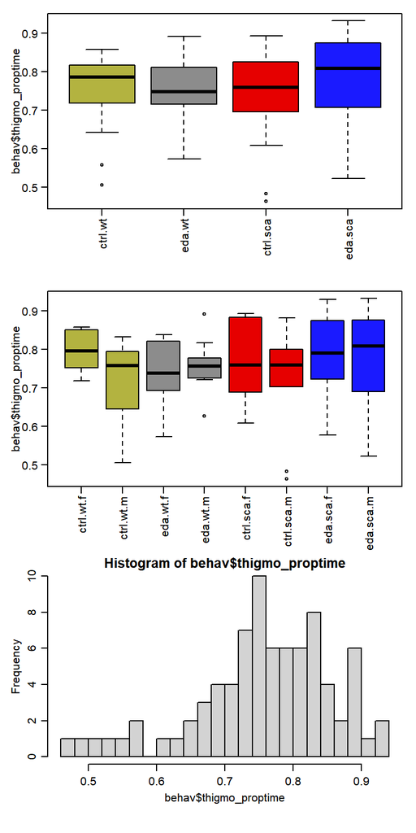

```r
## set spacing
par(mar=c(5,3.5,1,1))
par(mgp=c(1.9,0.7,0))
par(mfrow=c(3,1))

## plotting
plot(behav$thigmo_proptime ~ behav$group,las=2,xlab="",
     col=cola)

plot(behav$thigmo_proptime ~ behav$group_sex,las=2,xlab="",
     col=cola[c(1,1,2,2,3,3,4,4)])

hist(behav$thigmo_proptime, 20)
```

No apparent effect of sex. Data distribution has tail around the 0.5 value, expectable for data of proportion concentrated close to 0-1 bound. Thus, beta regression is indicated.

## 7.2 Modelling

### 7.2.1 Prior specification

In the study Tichanek et al., time thigmotaxis was not main outcome and was confounded with distance walked. The previous data will not be used for prior

```r
behav$group<-relevel(behav$group,ref='ctrl.sca')

logit(mean(behav$thigmo_proptime))
```

```
[1] 1.13492
```

```r
sd(logit(behav$thigmo_proptime))*5
```

```
[1] 2.894561
```

Setting prior

```r
prior01 <- c(set_prior("student_t(3,1.13, 2.89)", class = "b", coef = "Intercept"),
             set_prior("normal(0, 2)", class = "b", coef = "groupctrl.wt"),
             set_prior("normal(0, 2)", class = "b", coef = "groupeda.wt"),
             set_prior("normal(0, 1.2)"  , class = "b", coef = "groupeda.sca"))
```

### 7.2.2 Model fit and diagnostics

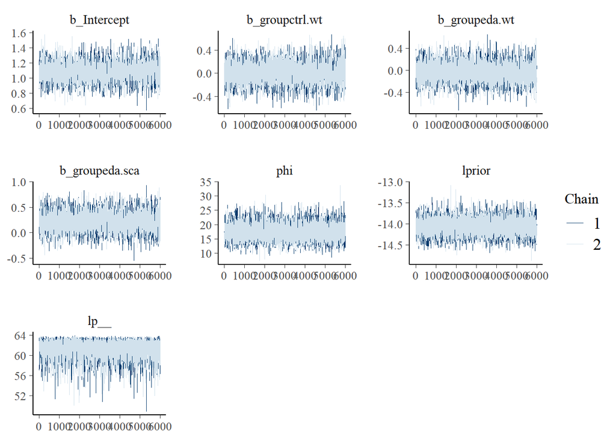

```r
of_thigmo_time_model_01<-run_model(
              brm(thigmo_proptime ~0+Intercept+group,
                        data=behav, prior = prior01,
                        family=Beta(link="logit", link_phi="log"),
                        save_pars = save_pars(all = TRUE),
                        iter=8000, warmup=2000,chains=2,cores=1,seed=17,
                        control = list(adapt_delta = 0.99)),
                  'output/brm/of_thigmo_time_model_01', reuse = TRUE)


mcmc_trace(of_thigmo_time_model_01)
```

```r
summary(of_thigmo_time_model_01)
```

```
 Family: beta
  Links: mu = logit; phi = identity
Formula: thigmo_proptime ~ 0 + Intercept + group
   Data: behav (Number of observations: 80)
  Draws: 2 chains, each with iter = 8000; warmup = 2000; thin = 1;
         total post-warmup draws = 12000

Population-Level Effects:
             Estimate Est.Error l-95% CI u-95% CI Rhat Bulk_ESS Tail_ESS
Intercept        1.09      0.12     0.86     1.32 1.00     3316     5084
groupctrl.wt     0.00      0.17    -0.32     0.34 1.00     4076     5473
groupeda.wt     -0.02      0.17    -0.36     0.31 1.00     4083     5731
groupeda.sca     0.22      0.17    -0.11     0.57 1.00     3951     6202

Family Specific Parameters:
    Estimate Est.Error l-95% CI u-95% CI Rhat Bulk_ESS Tail_ESS
phi    17.41      2.80    12.39    23.28 1.00     6795     7222

Draws were sampled using sampling(NUTS). For each parameter, Bulk_ESS
and Tail_ESS are effective sample size measures, and Rhat is the potential
scale reduction factor on split chains (at convergence, Rhat = 1).
```

Model converged and ESS are sufficient

### 7.2.3 PPC

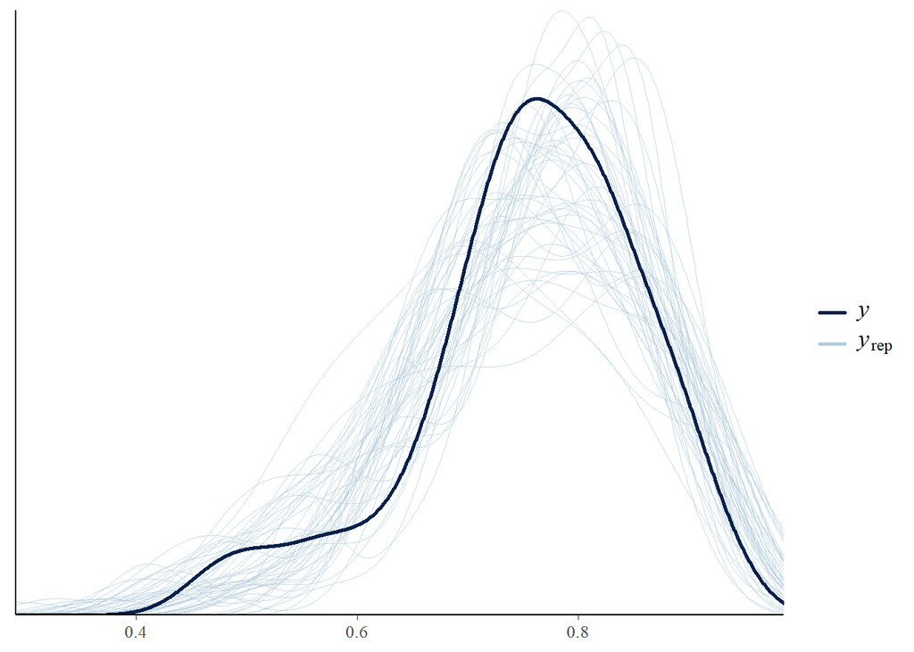

```r
pp_check(of_thigmo_time_model_01,type='dens_overlay',ndraws = 50)
```

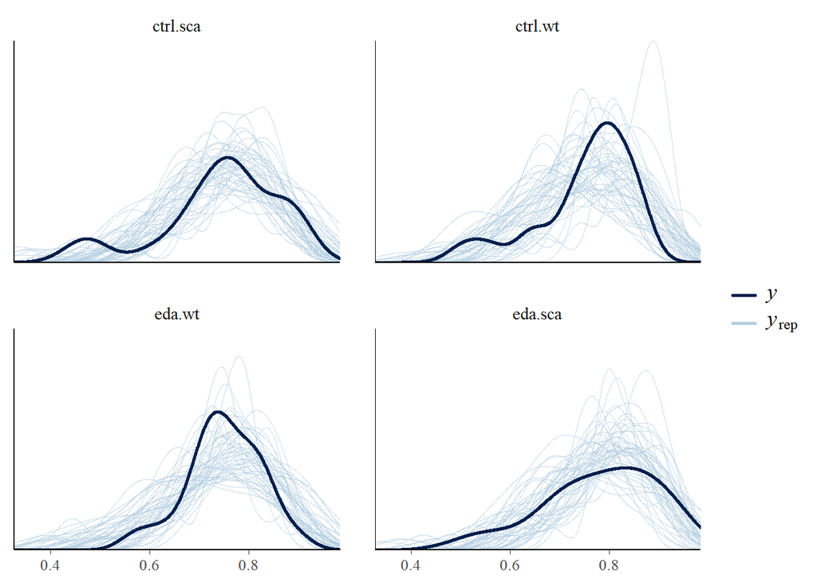

```r
pp_check(of_thigmo_time_model_01,type='dens_overlay_grouped',ndraws = 50,group='group')
```

```
Using all posterior draws for ppc type 'scatter_avg' by default.
```

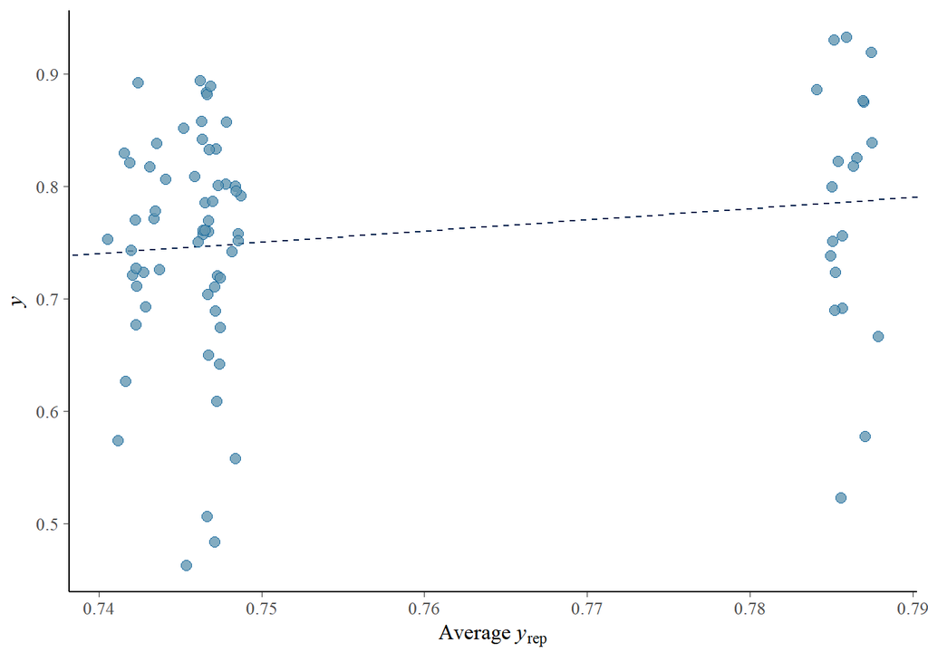

```r
pp_check(of_thigmo_time_model_01,type='scatter_avg')
```

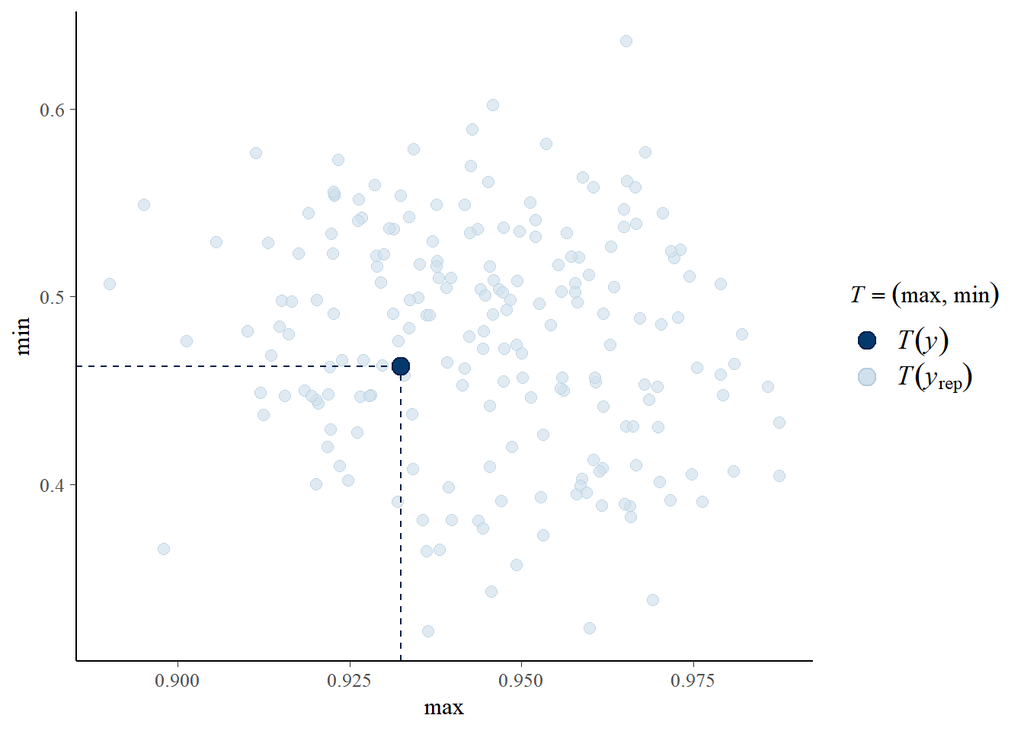

```r
pp_check(of_thigmo_time_model_01,type="stat_2d", stat = c("max", "min"),ndraws=200)
```

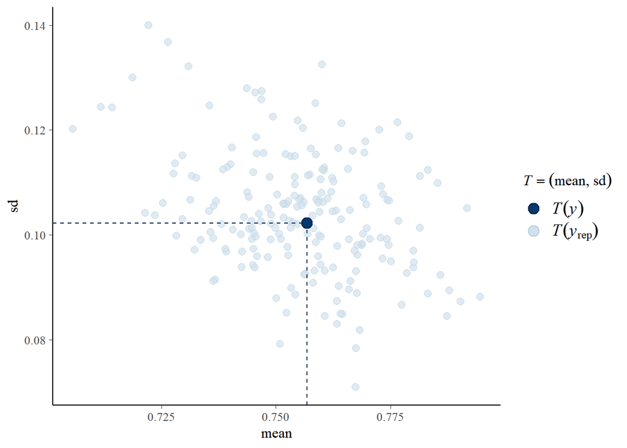

```r
pp_check(of_thigmo_time_model_01,type="stat_2d", stat = c("mean", "sd"),ndraws=200)
```

Model predicts the data well

## 7.3 Posterior draws extraction and vizualisation

Posterior extraction

```r
post_fix<-as.data.frame(of_thigmo_time_model_01, variable = c("b_Intercept","b_groupctrl.wt",
                                                         "b_groupeda.wt","b_groupeda.sca"))
names(post_fix)[1]<-"sca_ctrl"

post_fix$wt_ctrl<-post_fix$sca_ctrl+post_fix$b_groupctrl.wt
post_fix$wt_eda<-post_fix$sca_ctrl+post_fix$b_groupeda.wt
post_fix$sca_eda<-post_fix$sca_ctrl+post_fix$b_groupeda.sca
post_fix$wt_contrast<-post_fix$wt_eda-post_fix$wt_ctrl
summary(post_fix)
```

```
    sca_ctrl      b_groupctrl.wt      b_groupeda.wt      b_groupeda.sca
 Min.   :0.5749   Min.   :-0.638285   Min.   :-0.72352   Min.   :-0.5474
 1st Qu.:1.0055   1st Qu.:-0.109775   1st Qu.:-0.13585   1st Qu.: 0.1029
 Median :1.0828   Median : 0.001793   Median :-0.02158   Median : 0.2205
 Mean   :1.0853   Mean   : 0.003648   Mean   :-0.02241   Mean   : 0.2206
 3rd Qu.:1.1642   3rd Qu.: 0.114611   3rd Qu.: 0.09074   3rd Qu.: 0.3354
 Max.   :1.5748   Max.   : 0.665536   Max.   : 0.65074   Max.   : 0.9281
    wt_ctrl           wt_eda          sca_eda        wt_contrast
 Min.   :0.6423   Min.   :0.5208   Min.   :0.7265   Min.   :-0.72352
 1st Qu.:1.0066   1st Qu.:0.9816   1st Qu.:1.2181   1st Qu.:-0.13826
 Median :1.0871   Median :1.0599   Median :1.3023   Median :-0.02629
 Mean   :1.0889   Mean   :1.0628   Mean   :1.3058   Mean   :-0.02606
 3rd Qu.:1.1692   3rd Qu.:1.1410   3rd Qu.:1.3914   3rd Qu.: 0.08764
 Max.   :1.6426   Max.   :1.5603   Max.   :1.8698   Max.   : 0.63216
```

```r
groupquant<-sapply(post_fix[,c(5,6,1,7)],function(p) quantile(p, probs = c(0.025,0.975,0.5)))
groupquant<-inv.logit(groupquant)
```

Vizualisation

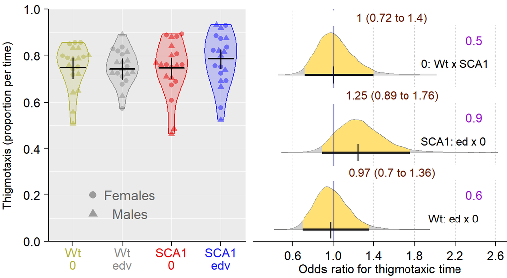

```r
## ordering of groups
behav$group<-factor(behav$group,levels=c('ctrl.wt','eda.wt','ctrl.sca','eda.sca'))

## plot spacing
par(mfrow=c(1,2))
par(mar=c(2,3,0,0))
par(mgp=c(2,0.6,0))

## scales setting
range<-c(0,1);scal<-range[2]-range[1]
xrange<-c(0.5,4.5);xscal=xrange[2]-xrange[1]

## plottting
plot(NULL,xlim=c(xrange[1],xrange[2]),ylim=c(range[1],range[2]),xlab="",
     ylab="Thigmotaxis (proportion per time)",las=1, axes=FALSE,cex.lab=1)

## theming
rect(xrange[1],range[2],xrange[2],range[1],col="grey92",border=NA)
x<-range[1]
repeat{
  lines(c(xrange[1],xrange[2]),c(x,x),col="white",lwd=0.7)
  x=x+0.1;if(x>range[2]){break}}

x<-1
repeat{
  lines(c(x,x),c(range[1],range[2]),col="white",lwd=0.7)
  x=x+1;if(x>4.5){break}}


## data distribution across groups and showing datapoints
vioplot(behav$thigmo_proptime~behav$group,col=colb,at=c(1:4),add=T,
        border=cola,axes=FALSE,drawRect=F,lwd=1,wex=0.8)

beeswarm(behav$thigmo_proptime~behav$group,col=colc,at=c(1:4),add=T,pwpch=(16.5+behav$sex_num) )

## group-specific prediction and CI
tp<-(groupquant[3,])
xx<-1;wid=0.25
repeat{
  lines(c(xx-wid,xx+wid),c(tp[xx],tp[xx]),lwd=2,col="black");
  lines(c(xx,xx),c(groupquant[1,xx],groupquant[2,xx]),lwd=1.7,col="black")
  xx<-xx+1
  if(xx>4){break}}

## axes
tckk=-0.02
axis(2,las=2,cex.axis=1.1,at=seq(range[1],range[2],by=0.2),
     labels=c(rep("",length(seq(range[1],range[2],by=0.2)))),pos=xrange[1],tck=tckk)
axis(2,las=2,cex.axis=1.1,at=seq(range[1],range[2],by=0.2),pos=xrange[1],tck=tckk)

axis(side=1,las=1,cex.axis=1.1,at=c(seq(1,4,by=1)),
     labels=c(rep("",length(seq(1,4,by=1)))),pos=range[1],tck=tckk)
lines(c(xrange[1],xrange[2]),c(range[1],range[1]))

## labelling
text(c(1:4),c(rep(range[1]-0.046*scal,4)),xpd=T,cex=1.1,col=cola,
     c("Wt","Wt", "SCA1", "SCA1"))
ypo<-c(range[1]-0.1*scal,range[1]-0.1*scal)
text(c(1:4),c(ypo[1],ypo[2],ypo[1],ypo[2]),xpd=T,cex=1.1,col=cola,
     c("0","edv", "0", "edv"))

ypos<-0.2;xpos=1.4
points(xpos,ypos,pch=16,cex=1.4,col=rgb(0.4,0.4,0.4,alpha=0.6))
text(xpos+0.19*xscal,ypos,"Females",col="grey40",cex=1.2)
points(xpos,ypos-0.08*scal,pch=17,cex=1.4,col=rgb(0.4,0.4,0.4,alpha=0.6))
text(xpos+0.19*xscal,ypos-0.08*scal,"Males",col="grey40",cex=1.2)

## probability distributions
par(mar=c(2,0,0,0))
dif<-data.frame(post_fix$wt_contrast,post_fix$b_groupeda.sca,
                post_fix$b_groupctrl.wt)
dif<-exp(dif)

yla<-"Odds ratio for thigmotaxic time"
tckk=-0.018
ste<-seq(0.2,4,by=0.4)
mons_poste(dif,1)

zpos=seq(0,1,1/3)
xx=1;ind=0.3;xpol<-2.2
text(xpol,zpos[xx]+zpos[2]*ind,
     "Wt: ed x 0 ",cex=1)
xx=xx+1

text(xpol,zpos[xx]+zpos[2]*ind,
     "SCA1: ed x 0 ",cex=1)
xx=xx+1

text(xpol,zpos[xx]+zpos[2]*ind,
     "0: Wt x SCA1",cex=1)
```